# HW7

Heath Blackmon

3/8/2018

# Dataset 1

The first dataset (oaks.csv) that we are going to look at is a study on the impact of temperature and precipitation on the fauna  
of ancient oak trees in Europe.

The dataset includes 6 columns: 1. Country 2. Tree circumference 3. Mean temperature of the warmest quarter 4. Mean precipitation during the warmest quarter 5. Number of specialist species found 6. Number of generalist species found

## problem 1

Identify one positive and one negative correlate of the number of specialist species found in each tree.

```r
oak <- read.csv("Dropbox/gitrepos/coleoguy.github.io/teaching/expdes/hw-labs/data/oaks.csv")

cor.test(x=oak$specialist, y=oak$Circumference)
```

```
##
##  Pearson's product-moment correlation
##
## data:  oak$specialist and oak$Circumference
## t = 6.2145, df = 283, p-value = 1.837e-09
## alternative hypothesis: true correlation is not equal to 0
## 95 percent confidence interval:
##  0.2400033 0.4448057
## sample estimates:
##       cor
## 0.3465274
```

```r
cor.test(x=oak$specialist, y=oak$MeanTempWarmestQuart)
```

```
##
##  Pearson's product-moment correlation
##
## data:  oak$specialist and oak$MeanTempWarmestQuart
## t = 6.9626, df = 283, p-value = 2.335e-11
## alternative hypothesis: true correlation is not equal to 0
## 95 percent confidence interval:
##  0.2786141 0.4773968
## sample estimates:
##       cor
## 0.3824217
```

```r
cor.test(x=oak$specialist, y=oak$MeanPrecipWarmestQuart)
```

```
##
##  Pearson's product-moment correlation
##
## data:  oak$specialist and oak$MeanPrecipWarmestQuart
## t = -7.1556, df = 283, p-value = 7.167e-12
## alternative hypothesis: true correlation is not equal to 0
## 95 percent confidence interval:
##  -0.4855252 -0.2883450
## sample estimates:
##        cor
## -0.3914188
```

Using `cor.test` we find that temperature is positively correlated with number of specialists and that precipitation is negatively correlated with number of specialists. You may have chosen to first transform the data in some fashion to increase normality. In my exploration I didn’t find these very helpful and they did not change my conclusions from the cor.test.

## problem 2

Find the strongest correlate of total number of species found on a tree. Plot your result and report your statistical test.

```r
tot.sp <- oak$specialist+oak$generalist
cor.test(x=tot.sp, y=oak$Circumference)
```

```
##
##  Pearson's product-moment correlation
##
## data:  tot.sp and oak$Circumference
## t = 5.7953, df = 283, p-value = 1.816e-08
## alternative hypothesis: true correlation is not equal to 0
## 95 percent confidence interval:
##  0.2177655 0.4257854
## sample estimates:
##       cor
## 0.3257115
```

```r
cor.test(x=tot.sp, y=oak$MeanTempWarmestQuart)
```

```
##
##  Pearson's product-moment correlation
##
## data:  tot.sp and oak$MeanTempWarmestQuart
## t = 5.8918, df = 283, p-value = 1.083e-08
## alternative hypothesis: true correlation is not equal to 0
## 95 percent confidence interval:
##  0.2229178 0.4302087
## sample estimates:
##       cor
## 0.3305437
```

```r
cor.test(x=tot.sp, y=oak$MeanPrecipWarmestQuart)
```

```
##
##  Pearson's product-moment correlation
##
## data:  tot.sp and oak$MeanPrecipWarmestQuart
## t = -4.8442, df = 283, p-value = 2.097e-06
## alternative hypothesis: true correlation is not equal to 0
## 95 percent confidence interval:
##  -0.3806610 -0.1658577
## sample estimates:
##        cor
## -0.2767123
```

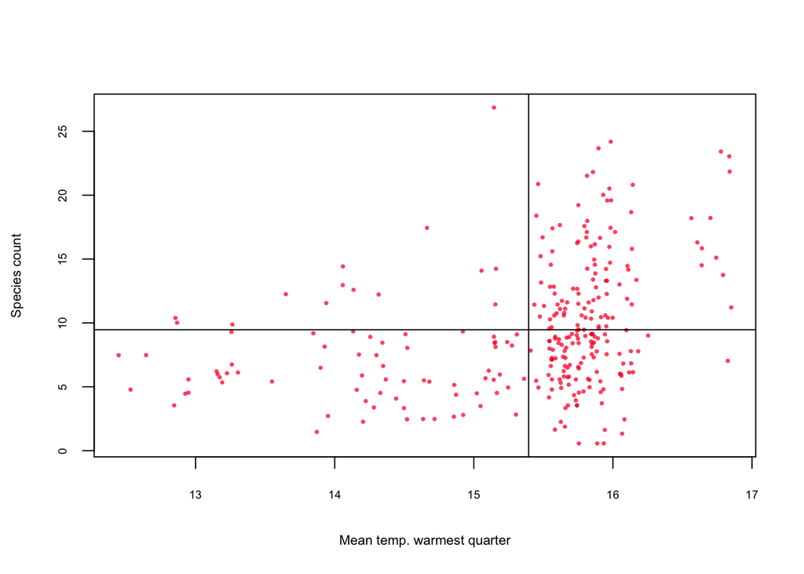

```r
plot(x=jitter(oak$MeanTempWarmestQuart, factor=3),
     y=jitter(tot.sp, factor=3),
     col=rgb(1,0,.2,.75),
     cex.lab=.7,
     cex.axis=.6,
     cex=.5,
     pch=16,
     ylab="Species count",
     xlab="Mean temp. warmest quarter")
abline(h=mean(tot.sp))
abline(v=mean(oak$MeanTempWarmestQuart))
```

Using Pearson’s correlation test we detect a significant correlation *p* < 0.001 and *R* = 0.33.

# Dataset 2

The second dataset (litter.csv) that we will be looking at today is focused on the impact of scavenging macroinvertebrates on leaf litter decay.

## Problem 3

Use what you have learned to analyze this dataset and make a statement about the impact of macroinvertebrates on leaf litter decay.

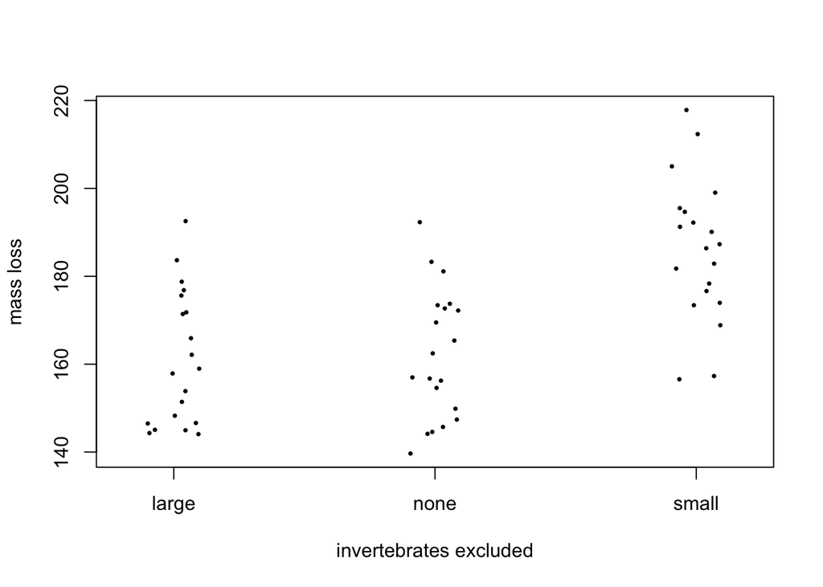

```r
lit <-  read.csv("Dropbox/gitrepos/coleoguy.github.io/teaching/expdes/hw-labs/data/litter.csv")
# really interested in the change
delta.mass <- lit$initial_mass - lit$final_mass
lit <- cbind(lit, delta.mass)

# as always VISUALIZE the data
stripchart(lit$delta.mass~lit$treatment,vertical=TRUE,method="jitter", pch=16, cex=.5,xlab="invertebrates excluded", ylab="mass loss")
```

My description of what these treatments were was a bit confusing sorry about that! What I wanted you to do though was find which if any of these are different and in this case we have blocking that we can take into account. Here is how we do that:

```r
fit <- lm(lit$delta.mass ~ lit$treatment + lit$block)
summary(aov(fit))
```

```
##               Df Sum Sq Mean Sq F value   Pr(>F)
## lit$treatment  2   8016    4008  16.943 1.76e-06 ***
## lit$block      1    234     234   0.989    0.324
## Residuals     56  13248     237
## ---
## Signif. codes:  0 '***' 0.001 '**' 0.01 '*' 0.05 '.' 0.1 ' ' 1
```

This shows us a significant effect of treatment but not block. We could also check if we met some of the anova assumptions

```r
library(car)
leveneTest(lit$delta.mass~lit$treatment)
```

```
## Levene's Test for Homogeneity of Variance (center = median)
##       Df F value Pr(>F)
## group  2  0.0057 0.9943
##       57
```

So our variances are not really very different good there. Lets follow up that anova with the Tukey test

```r
TukeyHSD(aov(fit))
```

```
##   Tukey multiple comparisons of means
##     95% family-wise confidence level
##
## Fit: aov(formula = fit)
##
## $`lit$treatment`
##               diff       lwr      upr     p adj
## none-large   1.069 -10.64102 12.77902 0.9737344
## small-large 25.037  13.32698 36.74702 0.0000104
## small-none  23.968  12.25798 35.67802 0.0000229
```

Taking this all together we should feel good about our ANOVA and we should say that the small treatment is significantly different than the other two.

# Dataset 3

The final dataset (fish.csv) for today looks at the fitness of fish from two different habitats (open water and shallow water).

## problem 4

What is the name for this type of experimental design

Full factorial

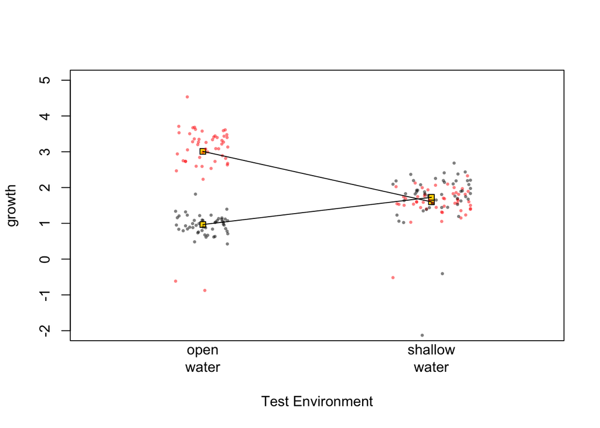

```r
fish <-  read.csv("Dropbox/gitrepos/coleoguy.github.io/teaching/expdes/hw-labs/data/fish.csv")
# really interested in the change
delta.mass <- fish$mass_2 - fish$mass_1
fish <- cbind(fish, delta.mass)

# as always VISUALIZE the data
plot(0,0,col="white",
           ylim=c(-2,5),
           xlim=c(.75,1.75),
           pch=16,
           cex=.5,
           xlab="Test Environment",
           ylab="growth",xaxt="n")
# overplot to get different color by native niche
oo <- mean(fish$delta.mass[1:50])
os <- mean(fish$delta.mass[51:100])
so <- mean(fish$delta.mass[101:150])
ss <- mean(fish$delta.mass[151:200])
points(pch=22,x=1,y=oo,bg="gold", col="black")
points(pch=22,x=1,y=so,bg="gold", col="black")
points(pch=22,x=1.5,y=os,bg="gold", col="black")
points(pch=22,x=1.5,y=ss,bg="gold", col="black")
x <- jitter(rep(1,50),factor=3)
points(x=x, y=fish$delta.mass[1:50],pch=16,cex=.5,col=rgb(1,0,0,.5))
points(x=x, y=fish$delta.mass[101:150],pch=16,cex=.5,col=rgb(0,0,0,.5))
x <- jitter(rep(1.5,50),factor=3)
points(x=x, y=fish$delta.mass[51:100],pch=16,cex=.5,col=rgb(1,0,0,.5))
points(x=x, y=fish$delta.mass[151:200],pch=16,cex=.5,col=rgb(0,0,0,.5))
lines(x=c(1,1.5), y=c(oo, os))
lines(x=c(1,1.5), y=c(so, ss))
axis(side=1, at=c(1,1.5),labels=c("open\nwater", "shallow\nwater"), tick = F)
```

## problem 5

Is there an interaction between the type of habitat fish are from and their performance in a new habitat?

Yes the lines cross so we can interpet this as an interaction.

## problem 6 plot this dataset

See above